# p3

**bueller**

Presentation 3: The Airing of Grievances

## The Agenda

1. Why everything I made this summer is terrible
2. How AI has already made all of us obsolete
3. My plan to ingratiate myself with our new robot overlords

## Erik-generated district report

[video not shown]

## What goes into one of these reports?

1. R code to crunch numbers (**fine**)
2. R code to make crunched numbers available to Quarto docs (**okay**)
3. R code to orchestrate the analysis and document generation (**mildly irritating**)
4. The report template files in Quarto (**rage-inducing**)

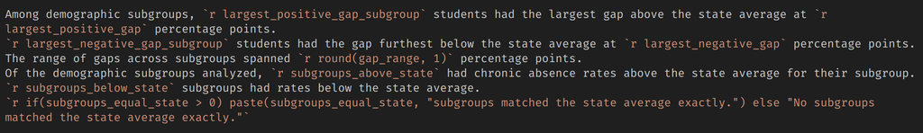

## What goes into one of these reports?

1. R code to crunch numbers (**fine**)
2. R code to make crunched numbers available to Quarto docs (**okay**)
3. R code to orchestrate the analysis and document generation (**mildly irritating**)
4. The report template files in Quarto (**rage-inducing**)

[figure not shown]

## Making Report Templates with Quarto

- Takes way too long

**You’re going to get annoyed and use AI for most of the writing**

- The user is definitely going to change them

**The user is going to use AI for most of the revisions**

Hot Take: Technical writing isn’t a job for humans anymore.

## The Robots are Here

Hand off tedious work to AI as soon as possible

1. Crunch the numbers
2. Store the results
3. Pass the results to an AI agent along with a simple prompt:

*Write a qmd file for an html document that can also be exported as docx. It should be a comprehensive report about chronic absenteeism in the district. Don’t editorialize, just report the results. It should be at least 1500 words long.*

## AI-Generated District Report

[video not shown]

There are some drawbacks, but I’m brave enough to ignore them.

[figure not shown]

→

AI makes one document  
(and boils the oceans)

→

[figure not shown]

## The Real Challenge

- Take the results of any analysis (not just absenteeism)
- Store them in one of the usual formats (.csv, .rds, .dta)
- Efficiently and reliably translate to LLM-readable format

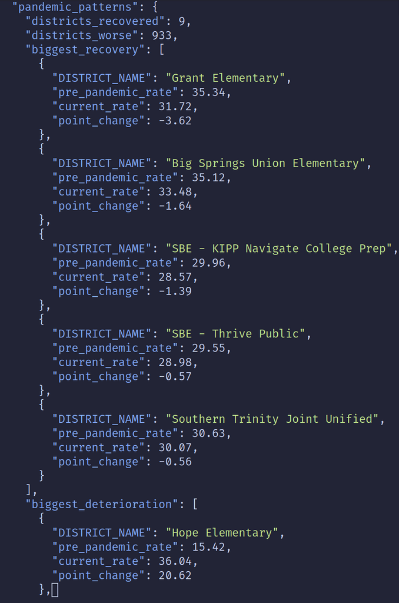

## Next Steps

**Make the application that:**

- Parses data files into JSON for LLMs
- Stores parsed data locally in a lightweight database
- Generates custom prompts from filtered data
- Handles APIs gracefully

## Next Steps

**Learn some 21<sup>st</sup> century skills:**

- Hardware needs for running LLMs locally (GPUs, RAM, etc.)
- Secure local networks for offline, isolated deployment
- Containerization and virtualization to isolate models from the sewer internet

[figure not shown]

Thank You